# Analisi Statistica del Dataset

Analista Dati

2025-02-08

```
## Rows: 112,958
## Columns: 30
## $ userid                  <chr> "2205529105", "2575562717", "15889875521737932…
## $ username                <chr> "AtomicMouse75", "LemarocN", "NewsExplorerFr",…
## $ acctdesc                <chr> NA, "Dites la vérité, toute la vérité, rien qu…
## $ location                <chr> NA, NA, "France", "Priay (01)", "France", "Cae…
## $ following               <dbl> 540, 187, 0, 2014, 50, 278, 0, 50, 355, 2581, …
## $ followers               <dbl> 195, 58, 26, 645, 1191, 59, 26, 1191, 5928, 11…
## $ totaltweets             <dbl> 6738, 8959, 18817, 91943, 103784, 4562, 18817,…
## $ usercreatedts           <dttm> 2013-11-20 20:09:03, 2014-06-01 15:41:06, 202…
## $ tweetid                 <chr> "1629270018817945600", "1629270210359205888", …
## $ tweetcreatedts          <dttm> 2023-02-25 00:00:17, 2023-02-25 00:01:03, 202…
## $ retweetcount            <dbl> 0, 0, 0, 0, 1, 0, 0, 1, 5, 1, 0, 0, 4, 1, 0, 0…
## $ text                    <chr> "Chers Ukrainiens,\nIl y a un an, vous avez su…
## $ hashtags                <chr> "[{'text': 'UkraineWillWin', 'indices': [242, …
```

[output cut: 17 more lines]

```
##     userid            username           acctdesc           location
##  Length:112958      Length:112958      Length:112958      Length:112958
##  Class :character   Class :character   Class :character   Class :character
##  Mode  :character   Mode  :character   Mode  :character   Mode  :character
##
##
##
##    following        followers         totaltweets
##  Min.   :     0   Min.   :       0   Min.   :      1
##  1st Qu.:   215   1st Qu.:     123   1st Qu.:   6308
##  Median :   686   Median :     507   Median :  22766
##  Mean   :  1616   Mean   :   14686   Mean   :  70916
##  3rd Qu.:  2015   3rd Qu.:    1712   3rd Qu.:  71688
##  Max.   :237024   Max.   :10593615   Max.   :4196373
##  usercreatedts                      tweetid
##  Min.   :2007-02-07 15:10:35.00   Length:112958
##  1st Qu.:2013-06-02 15:28:27.00   Class :character
##  Median :2018-04-21 23:52:34.50   Mode  :character
##  Mean   :2017-07-23 22:35:06.16
##  3rd Qu.:2021-11-11 00:39:49.00
##  Max.   :2023-03-03 18:20:43.00
##  tweetcreatedts                    retweetcount        text
##  Min.   :2023-02-25 00:00:17.00   Min.   :   0.0   Length:112958
##  1st Qu.:2023-02-26 11:26:29.50   1st Qu.:   5.0   Class :character
##  Median :2023-02-27 21:07:15.00   Median :  28.0   Mode  :character
##  Mean   :2023-02-28 08:17:47.33   Mean   : 191.8
##  3rd Qu.:2023-03-02 09:33:38.00   3rd Qu.: 161.0
##  Max.   :2023-03-03 23:59:52.00   Max.   :6698.0
##    hashtags           language         coordinates    favorite_count
##  Length:112958      Length:112958      Mode:logical   Min.   :    0.000
##  Class :character   Class :character   NA's:112958    1st Qu.:    0.000
##  Mode  :character   Mode  :character                  Median :    0.000
##                                                       Mean   :    1.219
##                                                       3rd Qu.:    0.000
##                                                       Max.   :11659.000
##  is_retweet    original_tweet_id  original_tweet_userid original_tweet_username
##  FALSE:18988   Length:112958      Length:112958         Length:112958
##  TRUE :93970   Class :character   Class :character      Class :character
##                Mode  :character   Mode  :character      Mode  :character
##
```

[output cut: 8 more lines]

```
##
##  is_quote_status quoted_status_id   quoted_status_userid quoted_status_username
##  FALSE:102151    Length:112958      Length:112958        Length:112958
##  TRUE : 10807    Class :character   Class :character     Class :character
##                  Mode  :character   Mode  :character     Mode  :character
##
##
##
##   extractedts                     sentiment       score
##  Min.   :2023-02-25 01:10:29.45   neg:76407   Min.   :0.3359
##  1st Qu.:2023-02-26 12:39:41.13   neu:17642   1st Qu.:0.5686
##  Median :2023-02-27 23:08:13.15   pos:18909   Median :0.7702
##  Mean   :2023-02-28 10:01:06.21               Mean   :0.7273
##  3rd Qu.:2023-03-02 11:10:45.02               3rd Qu.:0.8998
##  Max.   :2023-03-04 02:23:38.30               Max.   :0.9713
```

## **1. Analisi descrittiva di base**

- **Calcolo delle misure di tendenza centrale**: media, mediana, moda.
- **Calcolo delle misure di dispersione**: varianza, deviazione standard, range, interquartile range (IQR).
- **Minimo e massimo**: per avere una prima idea della distribuzione dei valori.
- **Coefficiente di variazione**: per valutare la dispersione rispetto alla media.
- **Percentili e quartili**: per identificare la distribuzione dei dati.

```
##                vars      n     mean        sd   median  trimmed      mad  min
## following         1 112958  1616.50   3098.48   686.00  1107.81   853.98 0.00
## followers         2 112958 14686.02 297700.05   507.00   930.46   687.93 0.00
## totaltweets       3 112958 70915.77 144023.86 22766.50 39161.61 29928.50 1.00
## retweetcount      4 112958   191.83    390.80    28.00    90.26    41.51 0.00
## favorite_count    5 112958     1.22     37.53     0.00     0.00     0.00 0.00
## score             6 112958     0.73      0.18     0.77     0.74     0.22 0.34
##                        max       range   skew kurtosis     se
## following        237024.00   237024.00  16.68   767.71   9.22
## followers      10593615.00 10593615.00  31.54  1070.53 885.77
## totaltweets     4196373.00  4196372.00   5.76    57.03 428.52
## retweetcount       6698.00     6698.00   3.21    12.26   1.16
## favorite_count    11659.00    11659.00 267.80 82445.15   0.11
## score                 0.97        0.64  -0.41    -1.21   0.00
```

## **2. Visualizzazione grafica preliminare**

- **Istogramma**: per osservare la forma della distribuzione.
- **Grafico Q-Q (Quantile-Quantile Plot)**: per confrontare la distribuzione empirica con una distribuzione teorica.
- **Boxplot** + **Violin plot**: per identificare la presenza di outlier.
- **Scatter plot (se la variabile è analizzata rispetto ad altre variabili)**.

**Strategie adottate:**

1. **Log-trasformazione** per variabili fortemente asimmetriche (`followers`, `following`, `totaltweets`, `retweetcount`, `favorite_count`) per migliorare la leggibilità dei grafici.
2. **Grafici separati per le variabili con e senza forte asimmetria.**

#### **Istogramma: Distribuzione dei dati**

📌Visualiziamo la distribuzione delle variabili per osservare le forti asimmetrie che fuoriescono dall’analisi generale.

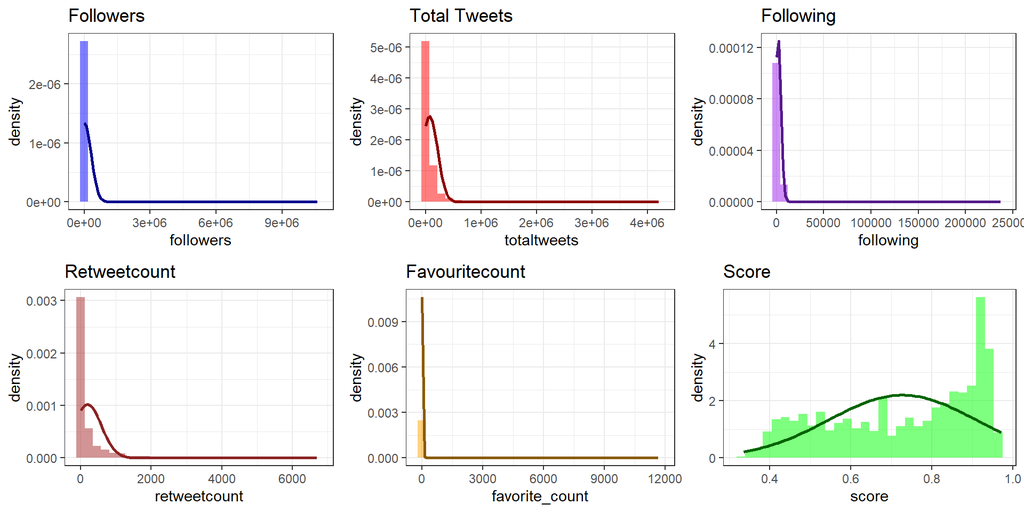

#### Trasformazione logaritmica

Osserviamo come cambia la distribuzione e gli outliers visualizzando l’histogramma e il boxplot con violin plot per ogni variabile in scala logaritmica

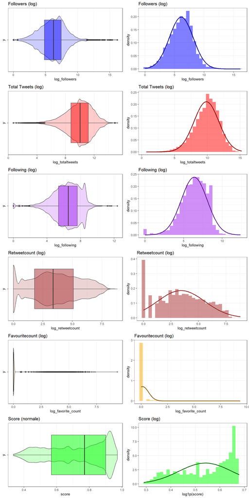

#### **Identificazione degli outlier**

Utilizziamo metodi specifici per l’estrapolazione degli outliers dalle variabili:

- **Boxplot e regola di Tukey (IQR Method)**: valori oltre 1.5*IQR dai quartili sono potenziali outlier.
- **Z-score (Standard Score)**: valori oltre ±3 possono essere considerati outlier.
- **Metodo di Hampel**: basato sulla mediana e la deviazione mediana assoluta (MAD).

```
##                              Variable IQR_Outliers ZScore_Outliers
## following                   following        10994            1146
## followers                   followers        12764             260
## totaltweets               totaltweets        11924            2623
## retweetcount             retweetcount        16686            3240
## favorite_count         favorite_count         8650             174
## score                           score            0               0
## log_followers           log_followers         1605             914
## log_following           log_following         1988            1631
## log_totaltweets       log_totaltweets         1912             874
## log_retweetcount     log_retweetcount            0               0
## log_favorite_count log_favorite_count         8650            3017
##                    Hampel_Outliers
## following                    17541
## followers                    19638
## totaltweets                  18450
## retweetcount                 29019
## favorite_count                8650
## score                            0
## log_followers                  965
## log_following                 1693
## log_totaltweets               1371
## log_retweetcount                 0
## log_favorite_count            8650
```

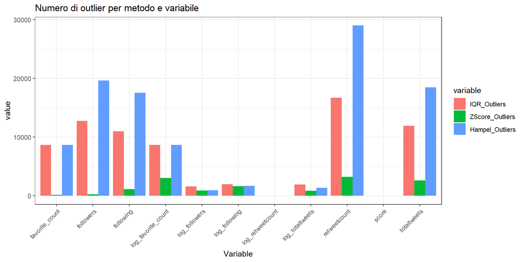

Osserviamo le distribuzioni logaritmiche finali prive di outliers

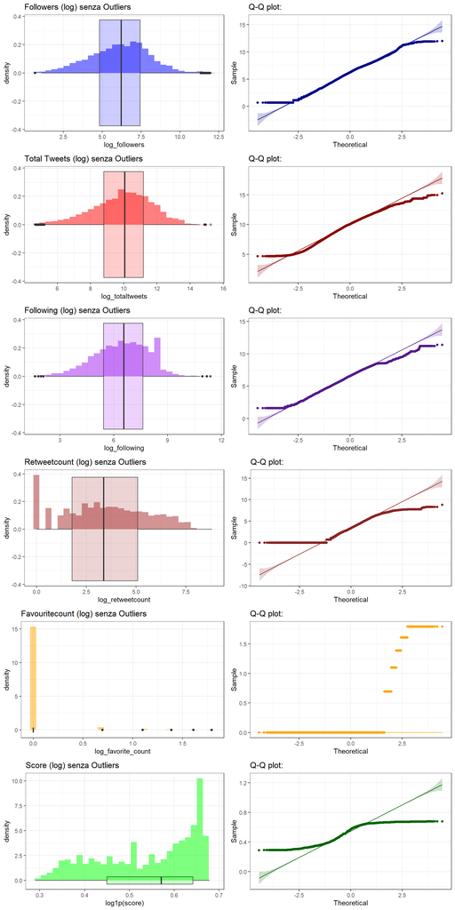

#### **Scatter Plot: Relazione tra variabili**

📌 **Verifichiamo se esistono correlazioni tra le variabili**.

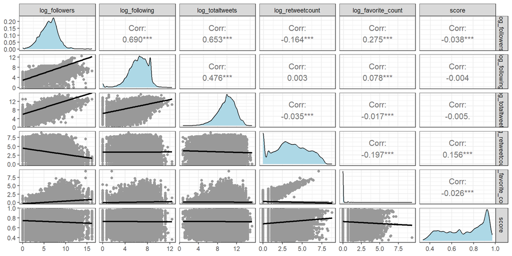

Notiamo che sono presenti delle relazioni lineari fra le variabili numeriche del dataset. Osserviamole meglio:

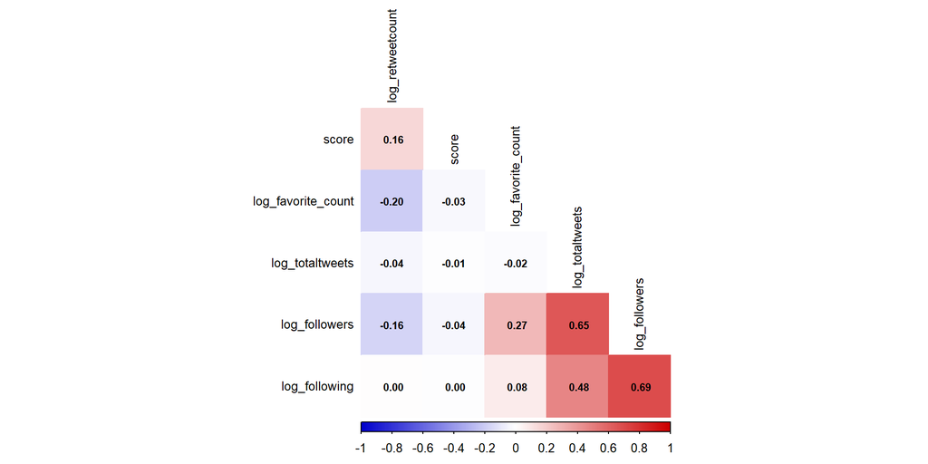

Osserviamo alcuni punti chiave:

🔹 **Correlazioni forti**

- **`log_followers` e `log_following` (0.69)** → Forte correlazione positiva: utenti con più follower tendono a seguire più persone.
- **`log_followers` e `log_totaltweets` (0.65)** → Chi ha più follower tende ad aver pubblicato più tweet.

🔸 **Correlazioni moderate**

- **`log_totaltweets` e `log_following` (0.47)** → Gli utenti che seguono molte persone tendono ad aver scritto più tweet.
- **`log_followers` e `log_favorite_count` (0.27)** → Una leggera correlazione positiva: chi ha più follower potrebbe ricevere più like sui post.

⚠️ **Correlazioni deboli o inverse**

- **`log_retweetcount` e `log_followers` (-0.16)** → Debole correlazione negativa: non necessariamente più follower significano più retweet.
- **`log_retweetcount` e `log_favorite_count` (-0.20)** → Tendenza inversa tra retweet e like: potrebbe indicare che alcuni tweet ricevono più retweet a discapito dei like.
- **`score` mostra correlazioni molto basse** con tutte le altre variabili, suggerendo che potrebbe non dipendere linearmente dalle metriche considerate.

#### Modello di Regressione Multipla (Score)

```
##
## Call:
## lm(formula = score ~ log_followers + log_following + log_totaltweets +
##     log_retweetcount + log_favorite_count, data = data)
##
## Residuals:
##      Min       1Q   Median       3Q      Max
## -0.41851 -0.15630  0.04709  0.16075  0.29161
##
## Coefficients:
##                      Estimate Std. Error t value Pr(>|t|)
## (Intercept)         0.6772650  0.0031974 211.819  < 2e-16 ***
## log_followers      -0.0033028  0.0004705  -7.020 2.23e-12 ***
## log_following       0.0010953  0.0004497   2.436   0.0149 *
## log_totaltweets     0.0018901  0.0003864   4.891 1.00e-06 ***
## log_retweetcount    0.0129034  0.0002572  50.164  < 2e-16 ***
## log_favorite_count  0.0045934  0.0010417   4.409 1.04e-05 ***
## ---
## Signif. codes:  0 '***' 0.001 '**' 0.01 '*' 0.05 '.' 0.1 ' ' 1
##
## Residual standard error: 0.1791 on 112952 degrees of freedom
## Multiple R-squared:  0.02471,    Adjusted R-squared:  0.02467
## F-statistic: 572.4 on 5 and 112952 DF,  p-value: < 2.2e-16
```

```
##
## Call:
## lm(formula = score ~ ., data = df)
##
## Residuals:
##      Min       1Q   Median       3Q      Max
## -0.45724 -0.11055  0.04229  0.12259  0.36567
##
## Coefficients:
##                       Estimate Std. Error  t value Pr(>|t|)
## (Intercept)          0.7790956  0.0028926  269.342  < 2e-16 ***
## log_followers       -0.0009601  0.0004145   -2.316  0.02056 *
## log_following        0.0010834  0.0004013    2.700  0.00694 **
## log_totaltweets     -0.0004537  0.0003412   -1.330  0.18369
## log_retweetcount     0.0142177  0.0002891   49.182  < 2e-16 ***
## log_favorite_count  -0.0101183  0.0010502   -9.635  < 2e-16 ***
## is_retweetTRUE      -0.0482994  0.0019139  -25.236  < 2e-16 ***
## is_quote_statusTRUE  0.0203032  0.0016245   12.498  < 2e-16 ***
## sentimentneu        -0.2140961  0.0013206 -162.118  < 2e-16 ***
## sentimentpos        -0.1426388  0.0012799 -111.444  < 2e-16 ***
## ---
## Signif. codes:  0 '***' 0.001 '**' 0.01 '*' 0.05 '.' 0.1 ' ' 1
##
## Residual standard error: 0.1571 on 112948 degrees of freedom
## Multiple R-squared:  0.2499, Adjusted R-squared:  0.2499
## F-statistic:  4182 on 9 and 112948 DF,  p-value: < 2.2e-16
```

**Modello 1 (solo variabili logaritmiche)**

- **`log_retweetcount` (+0.0129)** → L’aumento dei retweet ha il maggiore impatto positivo su `score`.
- **`log_favorite_count` (+0.0046)** → Anche i like hanno un effetto positivo.
- **`log_followers` (-0.0033)** → Controintuitivamente, un maggior numero di follower è associato a un punteggio inferiore.
- **Bassa capacità predittiva** (`R² Adjusted = 0.0247`), suggerisce che altre variabili non incluse sono più importanti.

**Modello 2 (logaritmi + categoriali)**

- **`is_retweetTRUE` (-0.0483)** → Se un tweet è un retweet, `score` diminuisce significativamente.
- **`is_quote_statusTRUE` (+0.0203)** → Se un tweet è una citazione, `score` aumenta.
- **`sentimentneu` (-0.2141)** e **`sentimentpos` (-0.1426)** → I tweet neutri e positivi hanno un impatto **negativo** su `score` rispetto ai negativi (riferimento), suggerendo che i tweet negativi potrebbero avere più engagement.
- **`log_retweetcount` (+0.0142)** → Ancora una volta, il numero di retweet è il miglior predittore positivo.
- **`log_favorite_count` (-0.0101)** → A differenza del Modello 1, ora ha un impatto negativo.

Il **Modello 2** è nettamente migliore rispetto al Modello 1 perché ha:

- **R² Adjusted molto più alto** (0.2499 vs 0.0247), indicando che spiega una maggiore parte della variabilità di `score`.
- **Residual Standard Error minore** (0.1571 vs 0.1791), il che suggerisce previsioni più precise.
- **Più variabili significative**, incluse le variabili categoriali `is_retweet`, `is_quote_status` e le emozioni `sentimentneu` e `sentimentpos`.

**Conclusioni**

1. **Il Modello 2 è nettamente migliore** in termini di spiegazione della variabilità e accuratezza.
2. **Le variabili categoriali (retweet, citazione, sentiment) sono molto influenti**, e il loro impatto sarebbe perso nel Modello 1.
3. **Il sentiment negativo sembra favorire `score`**, un risultato interessante per l’analisi dell’engagement.

```
##
## Call:
## lm(formula = score ~ ., data = df)
##
## Residuals:
##      Min       1Q   Median       3Q      Max
## -0.56613 -0.10804  0.03467  0.12730  0.36601
##
## Coefficients:
##                       Estimate Std. Error  t value Pr(>|t|)
## (Intercept)          7.754e-01  1.261e-03  614.792  < 2e-16 ***
## following           -1.911e-07  1.554e-07   -1.229    0.219
## followers            2.652e-09  1.569e-09    1.690    0.091 .
## totaltweets          3.205e-09  3.365e-09    0.952    0.341
## retweetcount         8.368e-05  1.229e-06   68.081  < 2e-16 ***
## favorite_count      -2.018e-05  1.238e-05   -1.629    0.103
## is_retweetTRUE      -8.555e-03  1.286e-03   -6.653 2.89e-11 ***
## is_quote_statusTRUE  1.958e-02  1.596e-03   12.268  < 2e-16 ***
## sentimentneu        -2.217e-01  1.305e-03 -169.922  < 2e-16 ***
## sentimentpos        -1.447e-01  1.265e-03 -114.396  < 2e-16 ***
## ---
## Signif. codes:  0 '***' 0.001 '**' 0.01 '*' 0.05 '.' 0.1 ' ' 1
##
## Residual standard error: 0.1557 on 112948 degrees of freedom
## Multiple R-squared:  0.2635, Adjusted R-squared:  0.2635
## F-statistic:  4491 on 9 and 112948 DF,  p-value: < 2.2e-16
```

#### Modello di Regressione Multipla (Sentiment)

**Interpretazione Generale**

- Il modello utilizza **il sentiment negativo come categoria di riferimento**.
- Le due righe nei coefficienti rappresentano:
  - **neu** → log-odds di un tweet essere **neutro** rispetto al negativo.
  - **pos** → log-odds di un tweet essere **positivo** rispetto al negativo.
- I coefficienti positivi indicano che **aumentano la probabilità di appartenere alla categoria rispetto al negativo**, mentre quelli negativi indicano una **maggiore probabilità di essere negativi**.

```
## Call:
## multinom(formula = sentiment ~ ., data = df)
##
## Coefficients:
##     (Intercept)     following    followers   totaltweets retweetcount
## neu    4.313617 -3.169184e-06 3.642267e-08  2.025952e-07 0.0009898930
## pos    2.254166  2.666995e-06 5.017576e-08 -3.145018e-08 0.0003579442
##     favorite_count is_retweetTRUE is_quote_statusTRUE     score
## neu  -1.471228e-04     -0.6464436          -0.1672124 -8.079341
## pos  -8.459557e-05     -0.1399560           0.2996696 -5.074524
##
## Std. Errors:
##      (Intercept)    following    followers  totaltweets retweetcount
## neu 3.281412e-08 2.958717e-06 2.895243e-08 6.244566e-08 1.978793e-05
## pos 3.089153e-08 2.607565e-06 2.742245e-08 5.987689e-08 2.087521e-05
##     favorite_count is_retweetTRUE is_quote_statusTRUE        score
## neu   1.167585e-04   2.599118e-08        4.453475e-09 1.824593e-08
## pos   8.434196e-05   2.606530e-08        4.987573e-09 1.950138e-08
##
## Residual Deviance: 163317.6
## AIC: 163353.6
```

[output not shown]

**1. Tweet Negativi (Categoria di Riferimento)**

**Possibile spiegazione**:

- I tweet negativi potrebbero essere più **polarizzanti e condivisibili** (maggiore interazione).
- Gli utenti molto attivi potrebbero essere più inclini a esprimere **opinioni critiche o lamentele**.

**2. Tweet Neutri**

**Fattori che riducono la probabilità di un tweet neutro:**

- **Score alto** → Un alto score riduce la probabilità di un tweet neutro (lo spinge verso il negativo).
- **Più “Mi piace” ricevuti** → I tweet che ricevono più apprezzamenti tendono a essere meno neutri (più polarizzati).
- **Citare altri tweet** → Se un tweet è una citazione, è meno probabile che sia neutro.

**3. Tweet Positivi**

**Fattori che aumentano la probabilità di un tweet positivo rispetto a uno negativo:**

- **Più follower** → Utenti con più follower hanno più probabilità di scrivere tweet positivi.
- **Citazioni di altri tweet** → Se un tweet cita un altro tweet, è più probabile che sia positivo.
- **Score leggermente più basso** → I tweet positivi tendono ad avere un punteggio più basso rispetto ai negativi.

**Fattori che riducono la probabilità di un tweet positivo:**

- **Più tweet totali** → Chi twitta molto tende meno a scrivere tweet positivi.
- **Più “Mi piace” ricevuti** → Sorprendentemente, i tweet con più like hanno **meno probabilità di essere positivi rispetto ai negativi**.
- **Retweet** → Se un tweet è un retweet, è meno probabile che sia positivo.

**Possibile spiegazione**:

- Gli utenti con più follower potrebbero avere **una community più favorevole e incoraggiante**.
- **Le citazioni potrebbero essere utilizzate per commentare in modo positivo un altro contenuto**.
- **I retweet sono spesso utilizzati per amplificare critiche**, quindi un tweet positivo è meno probabile se è un retweet.

### **3. Adattamento a distribuzioni note**:

- confronto con distribuzioni teoriche (normale, esponenziale, gamma, beta, ecc.).
- **Conoscere la distribuzione dei dati**
  - Permette di **capire la forma della distribuzione** (normale, esponenziale, gamma, beta, ecc.).
  - Aiuta a **semplificare l’interpretazione** dei dati e delle loro proprietà statistiche (asimmetria, varianza, ecc.).

  **Esempio:** Se una variabile segue una distribuzione **normale**, possiamo applicare direttamente la teoria della statistica classica (es. test parametrici).
- **Selezione di test statistici appropriati**
  - Alcuni test statistici **richiedono determinate ipotesi sulla distribuzione** (es. normalità per il test t di Student o ANOVA).
  - Se la distribuzione non è normale, possiamo scegliere test **non parametrici** più adeguati (es. test di Mann-Whitney).

  **Esempio:** Se la distribuzione dei dati è altamente asimmetrica, un **test di Wilcoxon** è più appropriato rispetto a un test t.
- **Modellazione e inferenza statistica**
  - Se i dati seguono una certa distribuzione, possiamo **fare previsioni** e **stimare probabilità** con modelli più semplici.
  - Molti algoritmi di Machine Learning assumono che i dati seguano determinate distribuzioni.

  **Esempio:** Se il tempo tra due eventi segue una **distribuzione esponenziale**, possiamo stimare il tasso di accadimento.
- **Generazione di dati sintetici (Simulazioni)**
  - Se una variabile segue una distribuzione teorica nota, possiamo **generare dati artificiali** per simulazioni e test di robustezza.

  **Esempio:** Se vogliamo simulare il comportamento di utenti su un sito web, possiamo campionare da una distribuzione simile a quella reale.

### **4. Analisi della distribuzione della variabile**

- **Test di normalità**:
  - Test di Shapiro-Wilk
  - Test di Kolmogorov-Smirnov
  - Test di Anderson-Darling
  - Test di Jarque-Bera
  - Test di Lilliefors
- **Metodi numerici per la normalità**:
  - Calcolo del coefficiente di Pearson della simmetria.
  - Confronto tra media e mediana (se molto distanti → possibile asimmetria).

### **6. Test delle ipotesi per caratteristiche statistiche importanti**

- **Test di uguaglianza della media**:
  - Test t di Student (se distribuzione normale)
  - Test di Mann-Whitney U (se distribuzione non normale)
  - Test di Wilcoxon (per dati appaiati)
- **Test di varianza**:
  - Test F di Fisher (confronto tra due varianze)
  - Test di Bartlett (per più gruppi con normalità)
  - Test di Levene (più robusto a violazioni della normalità)
  - Test di Fligner-Killeen (per dati non normali)
- **Test di omogeneità della distribuzione**:
  - Test del Chi-quadro
  - Test di Kolmogorov-Smirnov per due campioni.

### **7. Approfondimenti tramite modelli statistici**

- **Regressione lineare** (se si vuole verificare un’eventuale relazione lineare con altre variabili).
- **Regressione non lineare** (se i dati mostrano relazioni non lineari).
- **Regressione quantilica** (per analizzare effetti su diverse parti della distribuzione).
- **Anova e MANOVA** (se la variabile deve essere confrontata su più gruppi).
- **Modelli Bayesiani per inferenza probabilistica**.

### **8. Analisi della robustezza e stabilità**

- **Bootstrap resampling**: per valutare la stabilità delle stime statistiche.
- **Jackknife resampling**: per stimare l’errore di una statistica.
- **Analisi di sensitività**: per vedere come piccole variazioni influenzano i risultati.
- **Cross-validation**: se si usa un modello predittivo.

### **9. Analisi delle dipendenze non lineari e non parametriche**

- **Spline smoothing**: per identificare pattern non lineari.
- **Kendall’s Tau & Hoeffding’s D**: per dipendenze non lineari.
- **Analisi della dipendenza con mutual information**.

### **10. Analisi della qualità dei dati**

- **Percentuale di valori mancanti** e strategie di imputazione:
  - Sostituzione con media/mediana
  - KNN imputation
  - Modelli di regressione per imputazione
- **Controllo della presenza di duplicati e dati inconsistenti**.